# **HOMEWORK 1 (124 points + 1) : CAUTION! CONTENTS ARE HOT**

### **Part 5: Practice Quizzes (4 points)**

Complete the Knowledge check quizzes from **Chapter 4** and **Chapter 5** from the textbook available at [this link](https://ffalam.github.io/CMSC320TextBook/index.html). You can find them in the Summary of the Chapter tab.

Take a screenshot of each completed quiz page and attach them below. It's okay if the entire quiz is not visible in the screenshot.

#### Add the screenshot of chapter 4 knowledge check here

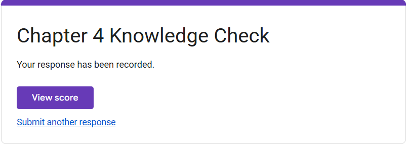

#### Add the screenshot of chapter 5 knowledge check here

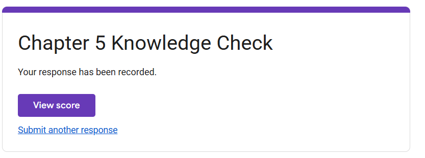

# Bonus(1 point): Assignment Submission with Jupyter Notebook file(ipynb) and PDF

In addition to the instruction of the special bonus question included exclusively in Assignment 1, we would like to highlight the importance of developing good practices for assignment submission in data science projects.

Think of yourself as a reviewer of your peers’ work: what would you pay attention to if you had to grade their assignments? Clearly, the raw dataset itself is not the main point—why would someone need to see every line of data you downloaded? Data science is about analysis and insight, not just data collection. What truly matters is how you analyze the data and how you present your results.

For a clean and effective submission, please avoid printing entire datasets unless they are directly relevant to the presentation of your output or if you are asked to do so. Instead, focus on:

- Showing your algorithm with clear, concise code
- Displaying the key results you want us to evaluate (or the outputs you relied on while working)
- Adding a short explanation when asked to interpret your findings

For this bonus question, please submit both your .ipynb file and the PDF version. To create a PDF: go to File (top left corner in Jupyter Notebook) → Print → Destination → Save as PDF.

Are you noticing an overwhelming amount of unnecessary printed results in your PDF? This is exactly why we emphasize the importance of cleaning up your work before submission. Removing trivial data printing makes your notebook look much more professional and easier to review—just like proofreading an essay for good grammar.

Your Homework 1 submission should be lightweight and focused, since this is a starter project designed to help you ease into the semester.

This practice helps us grade more efficiently and ensures fairness, since we can always reference your original notebook if regrading is needed.